# processing

### DAS Processing Demo

```python
# Import necessary dependencies
import os
import sys
import torch
import numpy as np
import matplotlib.pyplot as plt

from pathlib import Path
from scipy.signal import detrend
from scipy.signal import welch

sys.path.append('..')

from src.utils import nextpow2
from src.ani import bandpass_filter_tukey, temporal_normalization, spectral_whitening
```

```python
# Define paths
das_path1 = os.path.join('..', 'data', 'preprocessed', '20210901', '20210901_000000.npz')
das_path2 = os.path.join('..', 'data', 'preprocessed', '20210901', '20210901_001000.npz')
das_path3= os.path.join('..', 'data', 'preprocessed', '20210901', '20210901_002000.npz')
das_path4 = os.path.join('..', 'data', 'preprocessed', '20210901', '20210901_003000.npz')


ncf_path1 = os.path.join('..', 'data', 'ncf_raw_notebook', '20210901_000000_cc_000_conventional.npy')
ncf_path2 = os.path.join('..', 'data', 'ncf_raw_notebook', '20210901_001000_cc_000_conventional.npy')

das_paths = [das_path1, das_path2, das_path3, das_path4]
```

#### 1. DAS Visualization and the Space-Time Domain

Distributed Acoustic Sensing (DAS) turns a standard fiber optic cable into a dense array of thousands of seismic sensors. By sending pulses of laser light down the fiber and measuring the phase of the backscattered light, the interrogator unit can measure minute changes in the fiber's length.

Mathematically, if $u(x,t)$ represents the displacement of the fiber at position $x$ and time $t$, DAS typically measures the **axial strain** $\epsilon(x,t)$ or the **strain rate** $\dot{\epsilon}(x,t)$:

$$\epsilon(x,t) = \frac{\partial u(x,t)}{\partial x}$$

$$\dot{\epsilon}(x,t) = \frac{\partial \epsilon(x,t)}{\partial t} = \frac{\partial^2 u(x,t)}{\partial x \partial t}$$

In this section, we will load a 10-minute segment of raw DAS data. The data is structured as a 2D matrix where one dimension represents **space** (channel position along the fiber) and the other represents **time**.

```python
# Load das data
das_data = np.load(das_path1)

# Inspect variables inside
for key in das_data:
    print(f'{key}')
```

```
data
dt
t_axis
x_axis
event_files
event_time
pre_time
post_time
```

```python
# DAS interrogator parameters
dt = 0.004 # Sampling rate in sec (or 250 Hz)
gauge_len = 16.0
chann_len = 8.16
dx = chann_len
```

```python
# Extract das data (channels, time)
das_array = das_data['data']
dt = das_data['dt']                 # Sampling rate in sec
N = das_data['data'].shape[1]       # Number of samples
T = N * dt                      # Total duration

print('DAS array shape:', das_array.shape)
print('Time axis shape:', das_data['t_axis'].shape)
print('Channel positions:', das_data['x_axis'].shape)
print(f'Sampling rates: {dt} s')
print(f'Total duration: {T/60:.2f} minutes')
```

```
DAS array shape: (350, 157500)
Time axis shape: (157500,)
Channel positions: (350,)
Sampling rates: 0.004 s
Total duration: 10.50 minutes
```

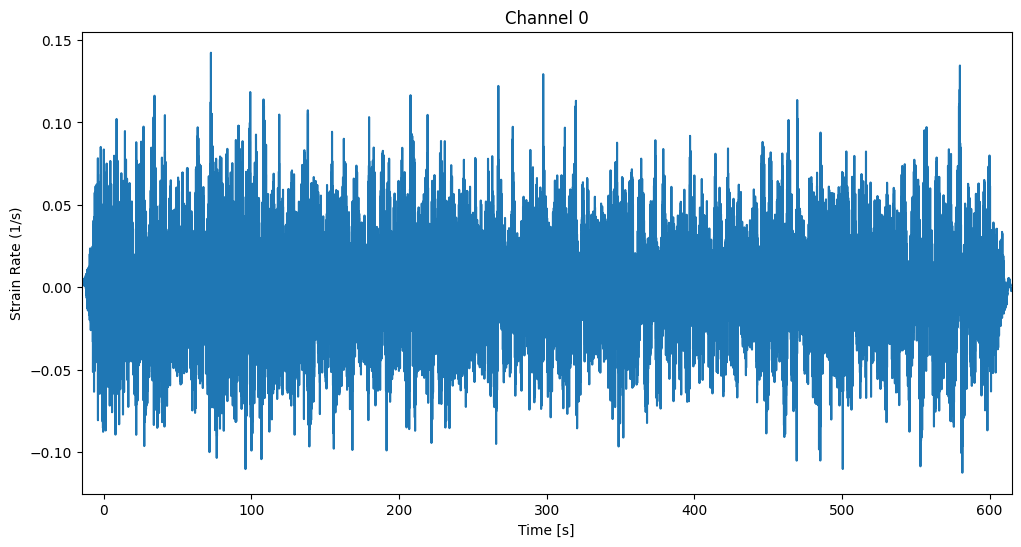

```python
# Plot single channel
ch_idx = 0
plt.figure(figsize=(12, 6))
plt.plot(das_data['t_axis'], das_data['data'][ch_idx])
plt.xlabel('Time [s]')
plt.ylabel('Strain Rate (1/s)')
plt.title(f'Channel {das_data["x_axis"][ch_idx]}')
plt.title(f'Channel {ch_idx}')
plt.xlim(das_data['t_axis'].min(), das_data['t_axis'].max())
plt.show()
```

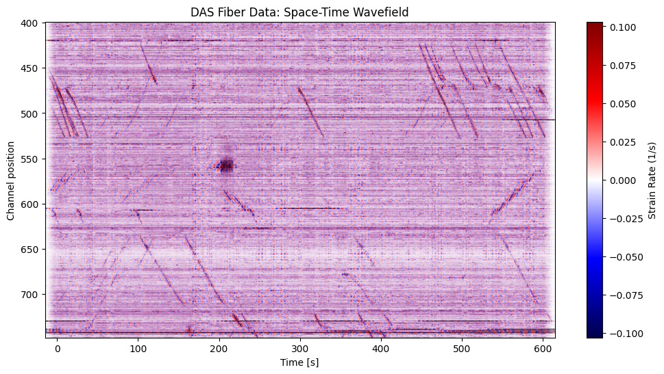

```python
# Compute clipping value to avoid extreme outliers in the colormap
pclip = 99
das_clip = np.percentile(np.abs(das_data['data']), pclip)

# Plot all channels as a heatmap
plt.figure(figsize=(12, 6))
plt.imshow(das_data['data'], aspect='auto',
           extent=[das_data['t_axis'][0], das_data['t_axis'][-1],
                   das_data['x_axis'][-1], das_data['x_axis'][0]],
                   vmin=-das_clip, vmax=das_clip,
           cmap='seismic')
plt.colorbar(label='Strain Rate (1/s)')
plt.xlabel('Time [s]')
plt.ylabel('Channel position')
plt.title('DAS Fiber Data: Space-Time Wavefield')
plt.show()
```

**Interpreting the Spatiotemporal Plot ($x$-$t$ domain)**

When we plot the DAS data matrix as a heatmap, we are looking at the wavefield in the **space-time domain**.

Notice prominent, straight diagonal lines crisscrossing the data. What are they?

These are **moving sources**, such as vehicles driving on a road parallel to our fiber array. In an $x$-$t$ plot, the apparent velocity $v_{app}$ of a propagating wave or a moving object is directly related to the slope of its signal:

$$v_{app} = \frac{\Delta x}{\Delta t}$$

**Key takeaways from the visual inspection:**

- **Diagonal Lines:** Represent energy propagating across the array.
- **Slope Direction:** A positive slope (going down and to the right) means a vehicle is traveling in one direction along the fiber, while a negative slope indicates travel in the opposite direction.
- **Steepness:** The steeper the line (less change in time for a given change in distance), the **faster** the vehicle is moving. Slower vehicles leave shallower, more drawn-out trails.
- **Horizontal Bands:** If we see horizontal lines that persist across all time, these are often "bad" channels or points of poor fiber coupling.

#### 2. Frequency Analysis: The Space-Frequency Domain

The raw DAS wavefield often contains a mixture of:

- **Low-frequency noise:** Temperature drifts, fiber strain relaxation, or instrumental $1/f$ noise (often below 0.1 Hz).
- **Signal of interest:** Microseisms, traffic noise, or local seismicity (typically between 1 Hz and 20 Hz).
- **High-frequency noise:** Optical fading or interrogator noise.

To separate these components, we transition from the space-time domain ($x$-$t$) to the space-frequency domain ($x$-$f$) using the **Discrete Fourier Transform (DFT)**. For a discrete time series $x[n]$, the Fourier transform $X(f)$ is:

$$X(f) = \sum_{n=0}^{N-1} x[n] e^{-i 2\pi f n \Delta t}$$

Rather than looking at the raw complex output, it is standard to analyze the **Power Spectral Density (PSD)**, which represents the distribution of power into frequency components. To handle the noisy nature of real signals, we estimate the PSD using **Welch's Method**, which divides the signal into overlapping segments, computes the periodogram for each, and averages them to reduce variance:

$$P(f) = \text{Average}\left( \frac{1}{T} |X_k(f)|^2 \right)$$

Because energy spans several orders of magnitude, we plot the PSD on a logarithmic scale (Decibels):

$$P_{dB}(f) = 10 \log_{10} \left( P(f) \right)$$

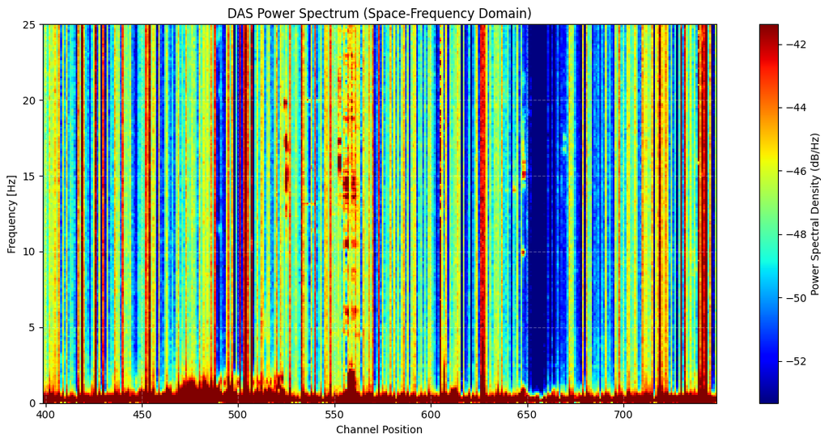

```python
# 1. Compute Power Spectral Density (PSD) using Welch's method
fs = 1.0 / dt  # Sampling frequency (250 Hz)

# nperseg controls the frequency resolution. Higher = finer frequency, but more variance.
# 2048 samples at 250 Hz gives a frequency resolution of ~0.12 Hz
freqs, psd = welch(das_array, fs=fs, nperseg=2048, axis=-1)

# Convert to Decibels (dB). We add a tiny epsilon (1e-12) to avoid log(0)
power_db = 10 * np.log10(psd + 1e-12)

# 2. Plotting the Power Spectrum
# Define the frequency range we actually care about (e.g., 0 to 25 Hz)
fmin, fmax = 0, 25
freq_mask = (freqs >= fmin) & (freqs <= fmax)

freqs_plot = freqs[freq_mask]
power_plot = power_db[:, freq_mask]

# Create a meshgrid for pcolormesh
X, Y = np.meshgrid(das_data['x_axis'], freqs_plot)

# Calculate color limits (e.g., 5th and 95th percentiles to drop extreme outliers)
vmin = np.percentile(power_plot, 5)
vmax = np.percentile(power_plot, 95)

plt.figure(figsize=(12, 6))
# Transpose power_plot (.T) so the axes align: (len(freqs_plot), len(channels))
mesh = plt.pcolormesh(X, Y, power_plot.T, cmap='jet', shading='auto', vmin=vmin, vmax=vmax)

plt.colorbar(mesh, label='Power Spectral Density (dB/Hz)')
plt.ylim(fmin, fmax)
plt.xlabel('Channel Position')
plt.ylabel('Frequency [Hz]')
plt.title('DAS Power Spectrum (Space-Frequency Domain)')

plt.grid(True, which='both', color='white', linestyle='--', alpha=0.3)
plt.tight_layout()
plt.show()
```

**1. The "Red Sea" at the Bottom (Horizontal Low-Frequency Band)** Look at the dark red band stretching horizontally across almost all channels below ~2 Hz.

- **What is it?** This represents very high energy at low frequencies. In DAS data, this is typically a combination of instrumental "1/f" noise (flicker noise from the interrogator laser), slow temperature variations acting on the fiber, and long-period oceanic microseisms.
- **Why it matters:** If we cross-correlate the raw data, this massive low-frequency energy will completely overwhelm the weaker, higher-frequency signals we actually want to use for imaging. This justifies our need for a **high-pass filter**.

**2. Vertical Stripes (Spatial Variations)** Notice the distinct vertical lines—some are bright red/yellow, while others are deep blue. Because these stripes span across *all* frequencies for a specific channel, they represent the physical reality of the fiber deployment:

- **Dark Blue Stripes (e.g., near channels 650–670):** These are "quiet" channels. This usually indicates **poor coupling** between the fiber and the ground. The cable might be hanging loose in a conduit, crossing a soft patch of dirt, or suffering from optical fading. It isn't picking up much acoustic energy.
- **Bright Red/Orange Stripes:** These are abnormally "loud" channels. This could mean the fiber is exceptionally well-coupled in tight sediments, or it is located right next to a continuous localized noise source (like a pump, a generator, or a busy intersection).

**3. Localized Broadband "Blobs"** Around channel 560, you can see a vertical column with speckles of high energy reaching up into the higher frequencies (10–20 Hz).

- **What is it?** This is likely a localized, broadband mechanical noise source that was active during this 10-minute recording window.

Seeing this spectrum perfectly justifies the next steps in ambient noise pipeline:

#### 2. DAS Processing

Before we can extract meaningful ambient noise cross-correlations, we must condition the raw data. Raw DAS recordings are riddled with instrumental artifacts, long-period thermal drifts, and common-mode noise.

The standard preprocessing pipeline:

1. **Detrending**
2. **Tapering & Bandpass Filtering**
3. **Decimation**
4. **Common Mode Noise Removal**

```python
# Set preprocessing parameters
fs              = 250        # sampling frequency (Hz)
f1, f2          = 0.5, 10    # bandpass filter corners
Decimation      = 1          # if not 1, decimation factor after filtering
diff = False                 # whether to differentiate (strain → strain rate)
min_length = 60              # length of the segment in preprocessing, in sec, if shorter than this length, skip the file
```

```python
# Extract a 60-second test window for visualization
test_duration_sec = 60.0
samples_test = int(test_duration_sec * fs)

# Ensure we don't exceed the actual data length
if das_array.shape[1] < samples_test:
    samples_test = das_array.shape[1]

x_raw = das_array[:, :samples_test].astype(np.float32)
m, n = x_raw.shape
print(f'Test Matrix shape: {m} channels x {n} samples')

# Time axis limit for plotting
t_max = samples_test * dt
channel_pos = das_data['x_axis']
```

```
Test Matrix shape: 350 channels x 15000 samples
```

##### 2.1 Detrend

**What it is:** Detrending removes the mean (or best-fit linear trend) from each individual channel's time-series independently.

**Why we do it:**

- **Baseline Correction:** DAS fibers are highly sensitive to slow temperature variations, which cause massive, long-period drifts in the baseline strain.
- **Filter Stability:** Digital filters (especially bandpass filters) perform poorly if the signal has a massive non-zero DC offset. Removing the trend ensures the baseline is exactly zero, preventing severe edge artifacts during Fourier transforms and convolutions.

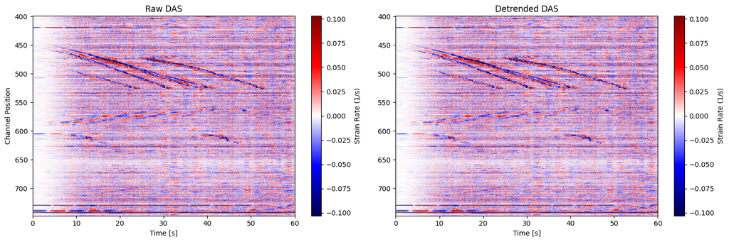

```python
# Remove the linear trend along the time axis (axis=-1)
x_detrended = detrend(x_raw, axis=-1)

fig, (ax1, ax2) = plt.subplots(1, 2, figsize=(15, 5))

# 1. Raw DAS
im1 = ax1.imshow(x_raw, aspect='auto', extent=[0, t_max, channel_pos[-1], channel_pos[0]],
                 vmin=-das_clip, vmax=das_clip, cmap='seismic')
ax1.set_title("Raw DAS")
ax1.set_xlabel("Time [s]")
ax1.set_ylabel("Channel Position")
fig.colorbar(im1, ax=ax1, label="Strain Rate (1/s)")

# 2. Detrended DAS
im2 = ax2.imshow(x_detrended, aspect='auto', extent=[0, t_max, channel_pos[-1], channel_pos[0]],
                 vmin=-das_clip, vmax=das_clip, cmap='seismic')
ax2.set_title("Detrended DAS")
ax2.set_xlabel("Time [s]")
fig.colorbar(im2, ax=ax2, label="Strain Rate (1/s)")

plt.tight_layout()
plt.show()
```

##### 2.2 Tukey-windowed bandpass filter

**What it is:** We apply a bandpass filter to isolate our frequency band of interest ($f_1$ to $f_2$). However, applying a filter directly to a truncated time series causes "spectral leakage" (ringing artifacts at the edges). To fix this, we multiply the data by a **Tukey Window** before filtering.

A Tukey window is a rectangular window with cosine-tapered edges. For a signal of length $N$ and a taper fraction $\alpha$ (where $0 \le \alpha \le 1$), the window $w[n]$ is defined as:

$$ w[n] = \begin{cases} \frac{1}{2}\left[1-\cos\left(\frac{2\pi n}{\alpha N}\right)\right], & 0 \le n < \frac{\alpha N}{2} \\ 1, & \frac{\alpha N}{2} \le n \le N - \frac{\alpha N}{2} \\ w[N-n], & \text{otherwise} \end{cases} $$

After tapering, we apply a Butterworth bandpass filter using the normalized cutoff frequencies: $$f_{\text{low}} = \frac{f_1}{f_{\text{Nyq}}}, \quad f_{\text{high}} = \frac{f_2}{f_{\text{Nyq}}}$$ where $f_{\text{Nyq}} = f_s / 2$ is the Nyquist frequency.

**Why we do it:**

- **Isolation:** The bandpass isolates the specific acoustic or seismic wavefield we want to study (e.g., 0.5 Hz to 10 Hz), discarding high-frequency optical noise and low-frequency thermal noise.
- **Edge Protection:** The Tukey taper smoothly brings the ends of our 60-second window to zero. Without it, the abrupt start/stop of the data would create high-frequency "clicks" that distort the Fourier spectrum.

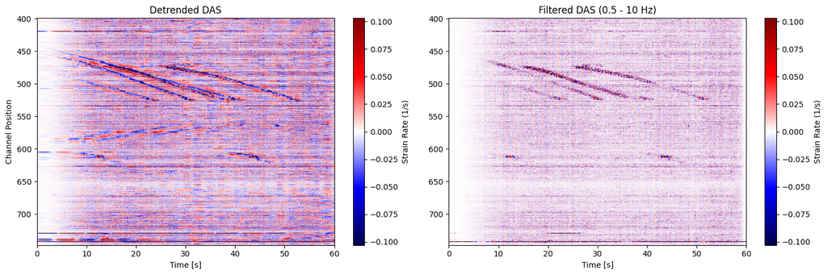

```python
# Apply Tukey window and Butterworth bandpass filter
x_filtered = bandpass_filter_tukey(x_detrended, fs=fs, f1=f1, f2=f2, alpha=0.05, order=4)

fig, (ax1, ax2) = plt.subplots(1, 2, figsize=(15, 5))

im1 = ax1.imshow(x_detrended, aspect='auto', extent=[0, t_max, channel_pos[-1], channel_pos[0]],
                 vmin=-das_clip, vmax=das_clip, cmap='seismic')
ax1.set_title("Detrended DAS")
ax1.set_xlabel("Time [s]")
ax1.set_ylabel("Channel Position")
fig.colorbar(im1, ax=ax1, label="Strain Rate (1/s)")

im2 = ax2.imshow(x_filtered, aspect='auto', extent=[0, t_max, channel_pos[-1], channel_pos[0]],
                 vmin=-das_clip, vmax=das_clip, cmap='seismic')
ax2.set_title(f"Filtered DAS ({f1} - {f2} Hz)")
ax2.set_xlabel("Time [s]")
fig.colorbar(im2, ax=ax2, label="Strain Rate (1/s)")

plt.tight_layout()
plt.show()
```

##### 2.3 Decimation

**What it is:** Decimation reduces the sampling rate of our data by keeping only every $D$-th sample. If our original sampling rate is $f_s$, the new effective sampling rate becomes:

$$f_{\text{new}} = \frac{f_s}{D}$$

*Note: True decimation requires applying an anti-aliasing low-pass filter before downsampling. However, because we already strictly bandpass filtered our data in the previous step (max 10 Hz), we can safely sub-sample the array directly without fear of aliasing.*

**Why we do it:**

- **Computational Efficiency:** DAS arrays generate massive volumes of data (e.g., 250 Hz * 10,000 channels). If our highest frequency of interest is 10 Hz, the Nyquist theorem states we only *need* a sampling rate of 20 Hz. Decimating drastically reduces memory usage and speeds up cross-correlation later.

```
Original fs: 250 Hz | Decimated fs: 250.0 Hz
```

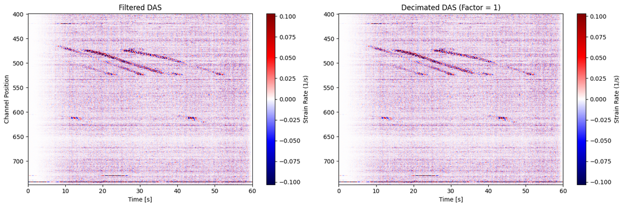

```python
# Keep every D-th sample (If Decimation = 1, this does nothing)
x_deci = x_filtered[:, ::Decimation]
fs_deci = fs / Decimation

print(f"Original fs: {fs} Hz | Decimated fs: {fs_deci} Hz")

fig, (ax1, ax2) = plt.subplots(1, 2, figsize=(15, 5))

im1 = ax1.imshow(x_filtered, aspect='auto', extent=[0, t_max, channel_pos[-1], channel_pos[0]],
                 vmin=-das_clip, vmax=das_clip, cmap='seismic')
ax1.set_title("Filtered DAS")
ax1.set_xlabel("Time [s]")
ax1.set_ylabel("Channel Position")
fig.colorbar(im1, ax=ax1, label="Strain Rate (1/s)")

im2 = ax2.imshow(x_deci, aspect='auto', extent=[0, t_max, channel_pos[-1], channel_pos[0]],
                 vmin=-das_clip, vmax=das_clip, cmap='seismic')
ax2.set_title(f"Decimated DAS (Factor = {Decimation})")
ax2.set_xlabel("Time [s]")
fig.colorbar(im2, ax=ax2, label="Strain Rate (1/s)")

plt.tight_layout()
plt.show()
```

##### 2.4 Common mode noise

**What it is:** Common-mode noise refers to disturbances that strike the entire fiber simultaneously, perfectly in-phase across all channels. This is usually non-acoustic noise originating from the interrogator itself (laser frequency drift) or vibrations physically shaking the interrogator rack.

To remove it, we calculate the spatial **median** across all channels at every time step, and subtract that median from the entire array.

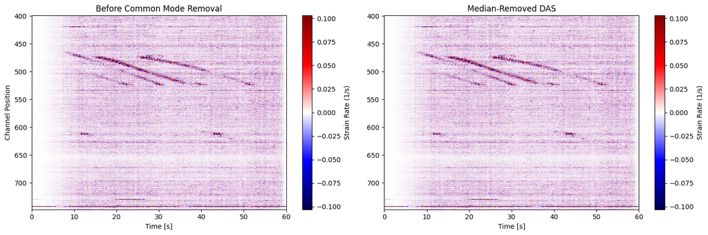

```python
# Calculate spatial median (axis=0) and subtract it from all channels
x_med = x_deci - np.median(x_deci, axis=0)

# Plotting Comparison
fig, (ax1, ax2) = plt.subplots(1, 2, figsize=(15, 5))

im1 = ax1.imshow(x_deci, aspect='auto', extent=[0, t_max, channel_pos[-1], channel_pos[0]],
                 vmin=-das_clip, vmax=das_clip, cmap='seismic')
ax1.set_title("Before Common Mode Removal")
ax1.set_xlabel("Time [s]")
ax1.set_ylabel("Channel Position")
fig.colorbar(im1, ax=ax1, label="Strain Rate (1/s)")

im2 = ax2.imshow(x_med, aspect='auto', extent=[0, t_max, channel_pos[-1], channel_pos[0]],
                 vmin=-das_clip, vmax=das_clip, cmap='seismic')
ax2.set_title("Median-Removed DAS")
ax2.set_xlabel("Time [s]")
fig.colorbar(im2, ax=ax2, label="Strain Rate (1/s)")

plt.tight_layout()
plt.show()
```

##### 2.5 Temporal Normalization

**What it is:** Temporal normalization suppresses the amplitude of high-energy, transient events in the time domain. There are two primary methods used in ambient noise interferometry:

1. **One-Bit Normalization (`ram_win = 0`):** The most extreme form of normalization. We discard all amplitude information and keep only the phase (the sign of the signal). $$x_{\text{norm}}[n] = \text{sign}(x[n])$$
2. **Running Absolute Mean (RAM) Normalization (`ram_win > 0`):** A gentler approach. We compute a moving average of the absolute amplitude over a specific window length, and divide the raw signal by this smoothed envelope. $$x_{\text{norm}}[n] = \frac{x[n]}{\frac{1}{2N+1} \sum_{k=-N}^{N} |x[n-k]|}$$ *Rule of thumb:* The RAM window length is usually chosen to be around half to one-fifth of the longest period in our bandpass filter (e.g., $1/f_1 / 5$ to $1/f_1 / 2$).

**Why we do it:** If a heavy truck drives over the fiber array, or an earthquake occurs, the amplitude of that event might be orders of magnitude larger than the background ambient noise. If we cross-correlate raw data, these loud transients will completely dominate the result. Temporal normalization forces the cross-correlation to focus on the continuous, stationary background noise rather than the loud, discrete events.

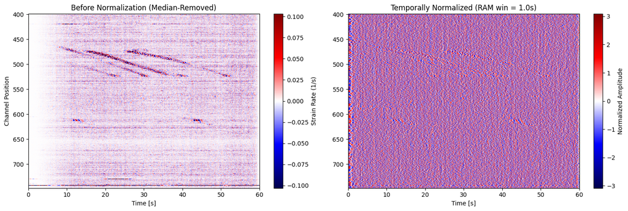

```python
# Set RAM window length (seconds)
# If 0.0, the function applies 1-bit normalization.
ram_win = 1.0

# Apply temporal normalization
x_tem_norm = temporal_normalization(x_med, fs=fs_deci, window_time=ram_win)

fig, (ax1, ax2) = plt.subplots(1, 2, figsize=(15, 5))

# We use the previously calculated das_clip for the Before plot
im1 = ax1.imshow(x_med, aspect='auto', extent=[0, t_max, channel_pos[-1], channel_pos[0]],
                 vmin=-das_clip, vmax=das_clip, cmap='seismic')
ax1.set_title("Before Normalization (Median-Removed)")
ax1.set_xlabel("Time [s]")
ax1.set_ylabel("Channel Position")
fig.colorbar(im1, ax=ax1, label="Strain Rate (1/s)")

# For the normalized plot, the amplitude scale has completely changed, so we recalculate limits
norm_clip = np.percentile(np.abs(x_tem_norm), 99)

im2 = ax2.imshow(x_tem_norm, aspect='auto', extent=[0, t_max, channel_pos[-1], channel_pos[0]],
                 vmin=-norm_clip, vmax=norm_clip, cmap='seismic')
ax2.set_title(f"Temporally Normalized (RAM win = {ram_win}s)")
ax2.set_xlabel("Time [s]")
fig.colorbar(im2, ax=ax2, label="Normalized Amplitude")

plt.tight_layout()
plt.show()
```

##### 2.6 Spectral whitening

**What it is:** Just as temporal normalization balances the energy across *time*, spectral whitening balances the energy across *frequencies*. We transform the data to the frequency domain and flatten the amplitude spectrum. There are two main modes:

1. **Phase-Only Whitening (`window_freq = 0.0`):** All amplitude information within the frequency band is forced to 1. Only the phase $\phi(f)$ is preserved. $$X_{\text{white}}(f) = e^{i\phi(f)}$$
2. **Running-Mean Amplitude Whitening (`window_freq > 0.0`):** Similar to RAM in the time domain, we compute a moving average of the amplitude spectrum over a frequency window and divide the raw spectrum by this smoothed version. $$X_{\text{white}}(f) = \frac{|X(f)|}{\text{smooth}(|X(f)|)} e^{i\phi(f)}$$

**Why we do it:** Ambient noise is rarely "white" (equal energy at all frequencies). Often, specific frequencies dominate (like a generator humming at a specific Hz, or the peak of the oceanic microseism). If we cross-correlate this "colored" noise, the resulting cross-correlation function will ring continuously at that dominant frequency, obscuring the precise arrival times of our seismic waves. Whitening broadens the bandwidth, resulting in much sharper, narrower pulses in the cross-correlation.

```python
# Set Whitening Parameters
is_spectral_whitening = True
window_freq = 0.0   # 0.0 = phase-only whitening; > 0 = running-mean amplitude whitening

device = torch.device("cpu")
X = torch.as_tensor(x_tem_norm, dtype=torch.float32, device=device)
nch, nt = X.shape

if is_spectral_whitening:
    # Choose FFT length (power-of-two is optimal for speed)
    nfft = nextpow2(nt)
    df = fs_deci / nfft  # Hz per frequency bin

    # Real FFT along the time axis
    R = torch.fft.rfft(X, n=nfft, dim=-1)

    # Apply spectral whitening (from our custom function)
    Rw = spectral_whitening(
        rfftdata=R,
        df=float(df),
        window_freq=float(window_freq),
        f1=float(f1),
        f2=float(f2),
    )

    # Inverse FFT back to time domain, and crop padded values
    Xw = torch.fft.irfft(Rw, n=nfft, dim=-1)[..., :nt]
else:
    Xw = X

x_whiten = Xw.detach().cpu().numpy().astype(np.float32, copy=False)
```

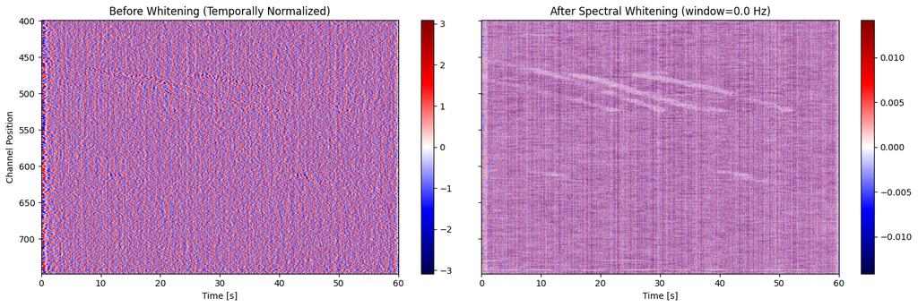

```python
# ---------------------------------------------------------
# 1. Visualization: Wavefield Before vs. After Whitening
# ---------------------------------------------------------
clip0 = np.percentile(np.abs(x_tem_norm), 99)
clip1 = np.percentile(np.abs(x_whiten), 99)

fig, axes = plt.subplots(1, 2, figsize=(15, 5), sharey=True)

im0 = axes[0].imshow(x_tem_norm, aspect="auto", extent=[0, t_max, channel_pos[-1], channel_pos[0]],
                     vmin=-clip0, vmax=clip0, cmap="seismic")
axes[0].set_title("Before Whitening (Temporally Normalized)")
axes[0].set_xlabel("Time [s]")
axes[0].set_ylabel("Channel Position")
fig.colorbar(im0, ax=axes[0])

im1 = axes[1].imshow(x_whiten, aspect="auto", extent=[0, t_max, channel_pos[-1], channel_pos[0]],
                     vmin=-clip1, vmax=clip1, cmap="seismic")
axes[1].set_title(f"After Spectral Whitening (window={window_freq} Hz)")
axes[1].set_xlabel("Time [s]")
fig.colorbar(im1, ax=axes[1])

plt.tight_layout()
plt.show()
```

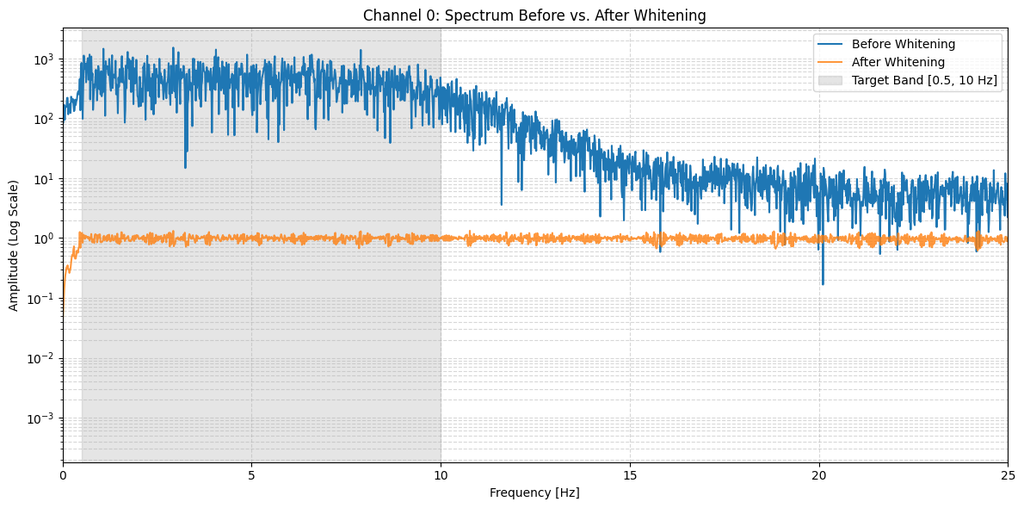

```python
# ---------------------------------------------------------
# 2. Visualization: Single Channel Spectrum Check
# ---------------------------------------------------------
ch = 0
freq = np.fft.rfftfreq(nfft, d=1.0/fs_deci)
A0 = np.abs(np.fft.rfft(x_tem_norm[ch], n=nfft))
A1 = np.abs(np.fft.rfft(x_whiten[ch], n=nfft))

plt.figure(figsize=(12, 6))
plt.semilogy(freq, A0 + 1e-12, label="Before Whitening")
plt.semilogy(freq, A1 + 1e-12, label="After Whitening", alpha=0.8)
plt.axvspan(f1, f2, alpha=0.2, color='gray', label=f"Target Band [{f1}, {f2} Hz]")
plt.xlim(0, min(fs_deci/2, 25)) # Focus on frequencies up to 25 Hz
plt.xlabel("Frequency [Hz]")
plt.ylabel("Amplitude (Log Scale)")
plt.title(f"Channel {ch}: Spectrum Before vs. After Whitening")
plt.legend()
plt.grid(True, which="both", ls="--", alpha=0.5)
plt.tight_layout()
plt.show()
```

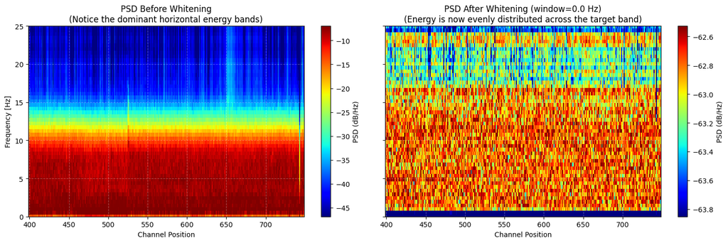

```python
# ---------------------------------------------------------
# 3. Visualization: Full Array PSD Check (Space-Frequency)
# ---------------------------------------------------------
# 1. Calculate PSD Before Whitening (Temporally Normalized Data)
freqs_b, psd_b = welch(x_tem_norm, fs=fs_deci, nperseg=512, axis=-1)
power_db_b = 10 * np.log10(psd_b + 1e-12)

# 2. Calculate PSD After Whitening
freqs_w, psd_w = welch(x_whiten, fs=fs_deci, nperseg=512, axis=-1)
power_db_w = 10 * np.log10(psd_w + 1e-12)

# Define frequency limits for plotting
fmin_plot, fmax_plot = 0, 25
freq_mask = (freqs_w >= fmin_plot) & (freqs_w <= fmax_plot)

# Create 2D meshgrid for pcolormesh
X_grid, Y_grid = np.meshgrid(channel_pos, freqs_w[freq_mask])

# Extract masked data for both
power_plot_b = power_db_b[:, freq_mask]
power_plot_w = power_db_w[:, freq_mask]

# Calculate independent color limits (whitening changes the absolute scale dramatically)
vmin_b, vmax_b = np.percentile(power_plot_b, 5), np.percentile(power_plot_b, 95)
vmin_w, vmax_w = np.percentile(power_plot_w, 5), np.percentile(power_plot_w, 95)

fig, axes = plt.subplots(1, 2, figsize=(15, 5), sharey=True)

# Before Whitening
mesh0 = axes[0].pcolormesh(X_grid, Y_grid, power_plot_b.T, cmap='jet', shading='auto', vmin=vmin_b, vmax=vmax_b)
fig.colorbar(mesh0, ax=axes[0], label='PSD (dB/Hz)')
axes[0].set_ylim(fmin_plot, fmax_plot)
axes[0].set_xlabel('Channel Position')
axes[0].set_ylabel('Frequency [Hz]')
axes[0].set_title('PSD Before Whitening\n(Notice the dominant horizontal energy bands)')
axes[0].grid(True, which='both', color='white', linestyle='--', alpha=0.3)

# After Whitening
mesh1 = axes[1].pcolormesh(X_grid, Y_grid, power_plot_w.T, cmap='jet', shading='auto', vmin=vmin_w, vmax=vmax_w)
fig.colorbar(mesh1, ax=axes[1], label='PSD (dB/Hz)')
axes[1].set_xlabel('Channel Position')
axes[1].set_title(f'PSD After Whitening (window={window_freq} Hz)\n(Energy is now evenly distributed across the target band)')
axes[1].grid(True, which='both', color='white', linestyle='--', alpha=0.3)

plt.tight_layout()
plt.show()
```

**1. Structural Shift: From Horizontal Bands to "Static"**

- **Before (Left):** The spectrum is dominated by thick, horizontal energy bands. The low frequencies (below 10 Hz) contain vastly more energy (red/yellow) than the higher frequencies (dark blue). If we cross-correlated this raw data, our result would be a long, ringing waveform dominated almost entirely by that specific low-frequency hum.
- **After (Right):** The horizontal bands are completely gone. The energy within our target bandpass ($f_1$ to $f_2$) now looks like speckled static. This means we have successfully turned our "colored" ambient noise into "white" noise, where every frequency bin contributes equally to the signal.

**2. The Dramatic Shift in Amplitude Scale**

- **Before (Left):** The dynamic range of the power spectrum is huge, spanning from roughly **-45 dB/Hz to -10 dB/Hz**. The low frequencies are thousands of times more energetic than the high frequencies.
- **After (Right):** Notice the drastically different scale on the right colorbar. The entire plot now spans an incredibly narrow range of roughly **-63.8 to -62.6 dB/Hz**. Because we used phase-only whitening (`window_freq = 0.0`), the algorithm literally forced the amplitude of every frequency bin to 1. The tiny remaining variations you see are just numerical artifacts from the Welch PSD estimation windowing.

**Why this matters for Cross-Correlation:** In Fourier theory, if a spectrum is perfectly flat (equal amplitude at all frequencies), its inverse Fourier transform is a sharp, narrow **Dirac delta function** (a spike). By forcing our noise spectrum to be flat, we ensure that our final cross-correlation functions will have the sharpest, most distinct seismic arrival peaks possible, making velocity picking much easier.

#### 3. Ambient Noise Cross-Correlation

##### 3.1 The Math of Cross-Correlation

For two discrete time series, $u_A[n]$ (recorded at channel $A$) and $u_B[n]$ (recorded at channel $B$), the cross-correlation function $C_{AB}$ as a function of time lag $k$ is:

$$C_{AB}[k] = \sum_{n} u_A[n] u_B[n+k]$$

We take the signal at channel $A$, slide the signal from channel $B$ over it by a time shift (lag) of $k$, multiply them together, and sum the result.

When the sliding signals align perfectly with a propagating wave, the multiplication yields a large positive number (a peak). The time lag $k$ where this peak occurs represents the exact travel time of the wave between the two channels!

##### 3.2 The "Virtual Source" (Reference Channel)

We do not have active sources (like dynamite or a hammer). Instead, we use ambient noise. Mathematical theory proves that if we cross-correlate long enough recordings of ambient noise between two sensors, the result approximates the **Green's Function** (the exact seismic wavefield) between them.

We treat one channel as the **Virtual Source (Reference Channel)** and correlate it against all other channels. Let's look at our physical array configuration along Sand Hill Road:

[figure not shown]

**Key Insight:** Because the lowest channel numbers start at the Northeast end, an **increasing channel index** means you are physically moving along the fiber from **Northeast to Southwest**.

If we choose **Channel 450** as our Virtual Source, we cross-correlate Channel 450 with 399, 400, 401... all the way to 748. The resulting 2D matrix looks exactly as if we had struck the fiber with a hammer at Channel 450 and recorded the waves propagating outwards!

*Computational Trick:* Correlating all 350 channels against each other takes a lot of compute. Therefore, we use a `src_stride = 10`. We only create Virtual Sources at every 10th channel (399, 409, 419...).

##### 3.3 Causal vs. Acausal (Anticausal) Lags

We calculate the cross-correlation for a maximum lag (e.g., `max_lag = 2.0` seconds). The lag axis ranges from $-2.0$ s to $+2.0$ s.

- **Causal Lags ($\tau > 0$):** Represents waves traveling *from* the Virtual Source *to* the Receiver.
- **Acausal Lags ($\tau < 0$):** Represents waves traveling *from* the Receiver *to* the Virtual Source.

**Geographical Example:** Let's assume Channel 450 is our Virtual Source and Channel 500 is our receiver. The distance is $(500 - 450) \times 8.16 = 408$ meters.

- **The Causal Lag ($\tau > 0$):** A wave arriving here traveled from Ch 450 to Ch 500. Geographically, this is energy moving **Northeast to Southwest (NE $\rightarrow$ SW)**. If a surface wave travels at $200$ m/s, we will see a peak at a causal lag of $\tau = +2.04$ seconds. This could be a vehicle driving away from El Camino Real.
- **The Acausal Lag ($\tau < 0$):** A wave arriving here traveled from Ch 500 to Ch 450. Geographically, this is energy moving **Southwest to Northeast (SW $\rightarrow$ NE)**. This could be morning commuter traffic heading down Sand Hill Road toward campus.

If the ambient noise field is perfectly uniform (noise arriving equally from all directions), the cross-correlation will be perfectly symmetric. However, if afternoon traffic leaving campus is much heavier than traffic arriving, the causal side (NE $\rightarrow$ SW) will be significantly stronger than the acausal side!

##### 3.4 Segmentation and Stacking

Ambient noise is random. To get a stable result, we chop our 10-minute file into 60-second segments (`xcorr_seg_sec = 60.0`), cross-correlate each 60-second chunk individually, and then average (stack) the results together.

```python
import numpy as np
import torch
from pathlib import Path

from src.ani import preprocess, TorchCrossCorrelation, whiten_per_segment_torch
from src.utils import convert_to_tensor, nextpow2

# Create output directory for saving results
out_dir = Path("../data/ncf_raw_notebook").resolve()
out_dir.mkdir(parents=True, exist_ok=True)

# ---------------------------------------------------------
# Configuration Parameters (Matching cc.yaml)
# ---------------------------------------------------------
# Preprocess params
fs_raw = 250.0
f1, f2 = 0.5, 10.0
Decimation = 1
diff = False
ram_win_sec = 1.0       # >0 for Running Absolute Mean normalization

# CC params
is_spectral_whitening = True
window_freq = 0.0       # 0.0 = Phase-only whitening
max_lag = 2.0           # Max lag to compute (+/- 2.0 seconds)
xcorr_seg = 60.0        # Segment length for stacking (seconds)

# Choose a Virtual Source index (e.g., local index 0 = absolute channel 399)
vs_idx = 0

# Device for notebook execution
device = torch.device("cpu")

# Helper: make symmetric lag slice for the conventional method
def _lag_slice_conventional(npts_seg: int, npts_lag: int) -> tuple[int, int]:
    L_full = 2 * npts_seg - 1
    center = npts_seg - 1
    lag_start = center - npts_lag
    lag_end = center + npts_lag + 1
    assert 0 <= lag_start < lag_end <= L_full
    return lag_start, lag_end

# ---------------------------------------------------------
# Processing Loop
# ---------------------------------------------------------
for das_path_str in das_paths: # Using the list defined in section 1
    das_path = Path(das_path_str).expanduser().resolve()
    print(f"\n=== Processing File: {das_path.name} ===")

    das = np.load(das_path)
    X_raw = das["data"].astype(np.float32, copy=False)  # Shape: (nch, npts)
    dt = float(das["dt"])
    fs_infer = 1.0 / dt

    if abs(fs_infer - fs_raw) > 1e-6:
        print(f"WARNING: config fs_raw={fs_raw} but file implies fs={fs_infer:.6f}")

    nch, npts = X_raw.shape
    print(f"  Raw shape: {X_raw.shape} | dt: {dt} s")

    # 1) One-command preprocess (Detrend, Filter, Decimate, Temporal Norm)
    X_proc = preprocess(
        x=X_raw,
        fs_raw=float(fs_raw),
        f1=float(f1),
        f2=float(f2),
        decimation=int(Decimation),
        diff=bool(diff),
        ram_win=float(ram_win_sec),
    ).astype(np.float32, copy=False)

    fs_proc = fs_raw / float(Decimation)
    nch2, npts2 = X_proc.shape
    assert nch2 == nch
    print(f"  Preprocessed shape: {X_proc.shape} | fs_proc: {fs_proc} Hz")

    # 2) Segmentation geometry for Cross-Correlation
    npts_lag = int(round(max_lag * fs_proc))
    npts_seg = int(round(xcorr_seg * fs_proc))

    if npts_lag <= 0 or npts_seg <= 0:
        raise ValueError("Bad npts_lag or npts_seg")
    if npts_lag >= npts_seg:
        raise ValueError(f"Need M < Nseg. Got M={npts_lag}, Nseg={npts_seg}")

    # Calculate how many 60-second segments fit into the recording
    npts_new = (npts2 // npts_seg) * npts_seg
    nseg = npts_new // npts_seg

    if nseg == 0:
        print("  SKIP: File too short after preprocessing for 60s segmentation.")
        continue

    # Trim excess samples that don't fit perfectly into a 60s window
    if npts_new != npts2:
        print(f"  Trimming {npts2 - npts_new} samples to fit segment boundaries.")
        X_proc = X_proc[:, :npts_new]
        npts2 = npts_new

    cc_out_len = 2 * npts_lag + 1
    lag_start, lag_end = _lag_slice_conventional(npts_seg, npts_lag)

    # Move to PyTorch tensor
    X_t = convert_to_tensor(X_proc, device=torch.device("cpu")).to(device)

    # 3) Spectral Whitening (applied per-segment before cross-correlation)
    if is_spectral_whitening:
        X_t = whiten_per_segment_torch(
            X_t,
            fs_proc=float(fs_proc),
            npts_seg=int(npts_seg),
            window_freq_hz=float(window_freq),
            f1=float(f1),
            f2=float(f2),
        )

    # 4) Initialize Cross-Correlation Model
    # NOTE: is_spectral_whitening=False here because we already whitened it manually above
    model = TorchCrossCorrelation(
        mode="conventional",
        max_lag_samples=None,
        is_spectral_whitening=False,
        whitening_params=None,
        v1_fft_snap_pow2=True,
        v1_fallback="v1_2M",
    ).to(device)
    model.eval()

    # 5) Compute CC for the Virtual Source against ALL channels
    # Output target shape: (nch, cc_out_len)
    ccall = np.zeros((nch, cc_out_len), dtype=np.float32)

    # Extract the virtual source trace
    src_trace = X_t[vs_idx:vs_idx+1, :]              # Shape: (1, npts2)
    full1 = src_trace.expand(nch, -1).contiguous()   # Shape: (nch, npts2)
    full2 = X_t.contiguous()                         # Shape: (nch, npts2)

    # Reshape into chunks of (Batch, Segment_Length)
    data1 = full1.reshape(nch * nseg, npts_seg)
    data2 = full2.reshape(nch * nseg, npts_seg)

    with torch.inference_mode():
        cc_full = model(data1, data2)                # Shape: (nch*nseg, 2*npts_seg-1)

    # Reshape and sum across the 'nseg' dimension (Stacking)
    cc_sum = cc_full.reshape(nch, nseg, -1).sum(dim=1)  # Shape: (nch, 2*npts_seg-1)

    # Slice out only the causal/acausal lags we care about (+/- 2.0s)
    cc_win = cc_sum[:, lag_start:lag_end]               # Shape: (nch, 2*M+1)

    ccall[:, :] = cc_win.detach().cpu().numpy()

    # Divide by number of segments to get the average (Linear Stack)
    ccall /= float(nseg)

    # 6) Save Output
    out_name = das_path.name.replace(".npz", f"_cc_{vs_idx:03d}_conventional.npy")
    out_path = out_dir / out_name
    np.save(out_path, ccall)
    print(f"  Saved: {out_path.name} | Shape: {ccall.shape} | Stacked {nseg} segments")

print("\nDone. Ready for visualization!")
```

```
=== Processing File: 20210901_000000.npz ===
  Raw shape: (350, 157500) | dt: 0.004 s
  Preprocessed shape: (350, 157500) | fs_proc: 250.0 Hz
  Trimming 7500 samples to fit segment boundaries.
  Saved: 20210901_000000_cc_000_conventional.npy | Shape: (350, 1001) | Stacked 10 segments

=== Processing File: 20210901_001000.npz ===
  Raw shape: (350, 157500) | dt: 0.004 s
  Preprocessed shape: (350, 157500) | fs_proc: 250.0 Hz
  Trimming 7500 samples to fit segment boundaries.
  Saved: 20210901_001000_cc_000_conventional.npy | Shape: (350, 1001) | Stacked 10 segments

=== Processing File: 20210901_002000.npz ===
  Raw shape: (350, 157500) | dt: 0.004 s
  Preprocessed shape: (350, 157500) | fs_proc: 250.0 Hz
  Trimming 7500 samples to fit segment boundaries.
  Saved: 20210901_002000_cc_000_conventional.npy | Shape: (350, 1001) | Stacked 10 segments

=== Processing File: 20210901_003000.npz ===
  Raw shape: (350, 157500) | dt: 0.004 s
  Preprocessed shape: (350, 157500) | fs_proc: 250.0 Hz
  Trimming 7500 samples to fit segment boundaries.
  Saved: 20210901_003000_cc_000_conventional.npy | Shape: (350, 1001) | Stacked 10 segments

Done. Ready for visualization!
```

#### 4. NCF Visualization

The resulting 2D matrix is called a **Virtual Shot Gather**.

In this specific file (`cc_000`), our Virtual Source is **Index 0** (Channel 399), which is located at the absolute Northeast start of our array (0.0 km).

**What to look for in the plot:**

- **The Origin (0m, 0s):** The autocorrelation of the Virtual Source with itself sits exactly at distance = 0 and lag = 0.
- **The Moveout (Diagonal Lines):** Because our Virtual Source is at the very edge of the array, waves can only travel in one direction along the fiber (Northeast $\rightarrow$ Southwest). We should see diagonal bands of energy sweeping downward and outward from the origin.
- **Causal vs. Acausal Asymmetry:** If traffic on Sand Hill Road is driving away from Channel 399 (NE $\rightarrow$ SW), the energy will appear on the **Causal (positive)** lag side. If traffic is driving toward Channel 399 (SW $\rightarrow$ NE), it will appear on the **Acausal (negative)** lag side.
- **Velocity:** The slope of these diagonal lines directly indicates the phase velocity of the surface waves passing through the ground!

```
Receiver channels: 350
Lag dimension: 1001 samples → 4.000 s total window
Processed sampling rate: 250.0 Hz → dt_proc = 0.0040 s
Lag axis (first/last): -2.000 s, 2.000 s
NCF data shape: (350, 1001)
```

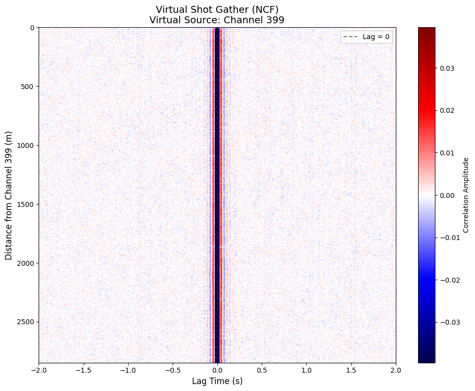

```python
# 1. Load NCF data
ncf_data = np.load(ncf_path1)

# Extract metadata
n_receivers, n_lags = ncf_data.shape

# Max lag and sample rate (matching our preprocessing settings)
max_lag = 2.0               # seconds
npts_lag = int(max_lag * fs_deci)

# Lag axis spans from -max_lag to +max_lag
lag_axis = np.linspace(-max_lag, max_lag, n_lags)

print(f'Receiver channels: {n_receivers}')
print(f'Lag dimension: {n_lags} samples → {2 * max_lag:.3f} s total window')
print(f'Processed sampling rate: {fs_deci:.1f} Hz → dt_proc = {1/fs_deci:.4f} s')
print(f'Lag axis (first/last): {lag_axis[0]:.3f} s, {lag_axis[-1]:.3f} s')
print('NCF data shape:', ncf_data.shape)

# 2. Define Cable Configuration
first_chan = 399
last_chan = 748
dx = 8.16  # Channel spacing in meters
channels = np.arange(first_chan, last_chan + 1)

# Fallback if the array length doesn't match expected metadata
if len(channels) != n_receivers:
    channels = np.arange(n_receivers)

# Create a physical distance axis relative to the start of the array
distance_axis = (channels - channels[0]) * dx

# 3. Compute clipping value using absolute values for a symmetric colormap
pclip = 99.0
ncf_clip = np.percentile(np.abs(ncf_data), pclip)

# 4. Plot the Virtual Shot Gather
plt.figure(figsize=(10, 8))

img = plt.imshow(ncf_data,
                 extent=[lag_axis[0], lag_axis[-1], distance_axis[-1], distance_axis[0]],
                 aspect='auto',
                 cmap='seismic',
                 vmin=-ncf_clip, vmax=ncf_clip,
                 interpolation='nearest')

plt.colorbar(img, label='Correlation Amplitude')
plt.xlabel('Lag Time (s)', fontsize=12)
plt.ylabel('Distance from Channel 399 (m)', fontsize=12)
plt.title(f'Virtual Shot Gather (NCF)\nVirtual Source: Channel 399', fontsize=14)

# Add a vertical line at Lag = 0 to separate Causal and Acausal
plt.axvline(0, color='black', linestyle='--', alpha=0.5, label='Lag = 0')
plt.legend(loc='upper right')

plt.tight_layout()
plt.show()
```

When we plotted the Virtual Shot Gather, we expected to see diagonal lines representing seismic waves propagating along the fiber. Instead, we see a dominant, bold vertical stripe perfectly aligned at **Lag = 0 seconds**, spanning across all distances.

What does this mean physically, and why did it happen?

**1. The Concept of "Infinite Apparent Velocity"** In a distance-time plot, the slope of a line represents velocity ($v = \frac{\Delta x}{\Delta t}$). A perfectly vertical line means that $\Delta t = 0$ across all distances. In other words, whatever caused this signal arrived at *every single channel in the entire 2.85 km array at the exact same instant*.

**2. What causes simultaneous arrivals?** There are two main culprits in DAS ambient noise interferometry:

- **Instrumental Artifacts (Most Likely):** DAS interrogators can suffer from internal electrical cross-talk or residual laser phase noise. Even though we applied a median subtraction (Common Mode Noise removal) during preprocessing, highly correlated optical noise can survive. Because it originates inside the interrogator box, it is recorded on every channel simultaneously, resulting in a massive correlation peak at exactly 0.0 seconds.
- **Broadside Acoustic/Seismic Sources:** If a loud acoustic wave (like a sonic boom or an airplane passing overhead) or a deep, teleseismic earthquake wavefront hits the earth perfectly perpendicular to the Sand Hill Road fiber, the wave strikes all channels at the same time.

**3. Where are our propagating waves?** The true seismic waves (the Green's Function) are likely still in this data! However:

- **SNR is still too low:** We only stacked 10 minutes of data (roughly ten 60-second segments). In traditional ambient noise interferometry, seismologists stack days, weeks, or even months of data to extract clear surface waves.
- **The Zero-Lag Peak is too loud:** The instrumental zero-lag artifact is so energetic that it completely washes out the color scale, making the fainter diagonal seismic waves invisible.

**Convert notebook to html**

```
python3 -m jupyter nbconvert --to html processing.ipynb
```